# Introduction to R

### Legend title

With labs

```r
ggplot(rp) +
  geom_point(aes(x=dipl_sup, y=cadres, color=pop_tot)) +
  labs(color="Population")
```

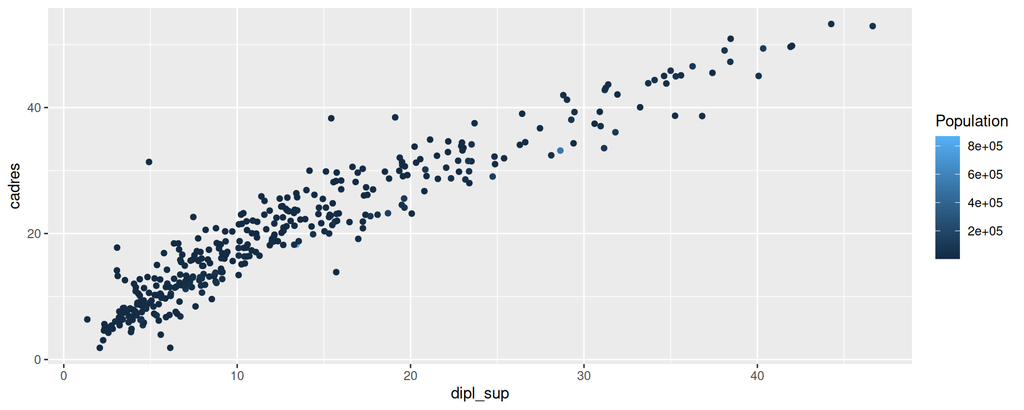

### Combining Figures with patchwork

```r
library(patchwork)

# Simple syntax to align plots
(p1 + p2) / p3 + plot_annotation(tag_levels = 'A')
```

### Statistical Visualization with ggstatsplot

- `ggstatsplot` creates information-rich plots that include statistical details (test results, effect sizes) directly in the graphic.
- Website: https://indrajeetpatil.github.io/ggstatsplot/

```r
library(ggstatsplot)

# Boxplot + Violin + Automated Statistical Test
ggbetweenstats(
  data = hdv2003,
  x = sport,
  y = age,
  title = "Distribution of Age by Sport Practice"
)
```

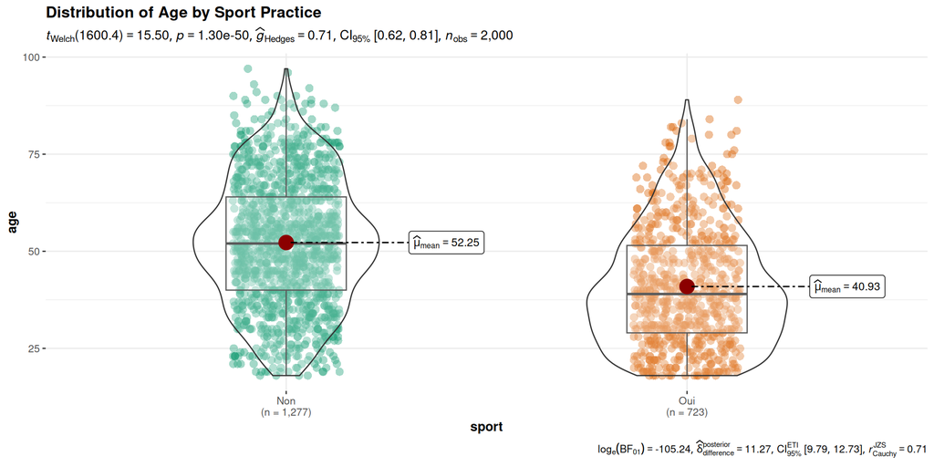

```r
ggpiestats(
  data = hdv2003,
  x = sport,
  y = sexe,
  title = "Composition of Sport Practice by Gender"
)
```

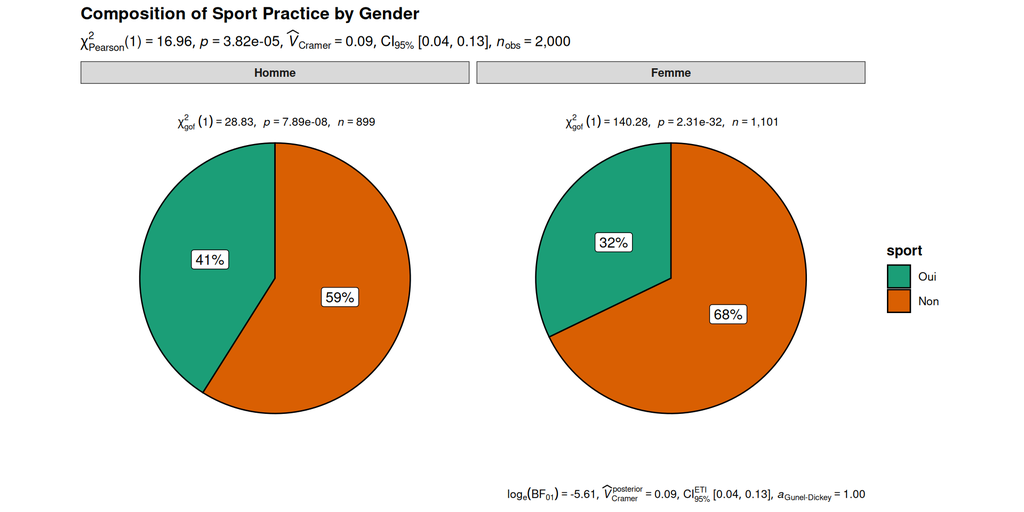

## 💻 Practice

With the dataset rp2018

- a geom_point with x=dipl_aucun and y=ouvr, with axes’ labels, and points in the blue color
- same graph than above with a color mapping on region
- boxplot: distribution of the variable proprio depending on the size of the department (pop_cl)
- geom_point with x=dipl_sup and y=cadres, with a graph for each region (facet_wrap)
- boxplot: distribution of the average proportion of owners by department inside each region

# Multivariate analysis

## Linear regression

Linear regression is a technique used for modelling the relationship between a dependent variable and one or more independent variables.

- performed using the `lm(formula, data)` function, where formula specifies the relationship between the variables, and data is the dataset
- the pattern: `y ~ x1 + x2 + ... + xn`, where `y` is the dependent variable and `x1, x2, ..., xn` are the independent variables
- R calculates the regression coefficients (slopes) and intercept to estimate the best-fit line that minimizes the sum of squared residuals
- The summary() function provides details about the linear regression model, including the coefficient estimates, standard errors, t-values, and p-values.
  - Estimate: coefficients of the independent variables
  - Std. Error: used to compute the confidence interval and the t-statistic
  - t value: the coefficient divided by the standard error
  - Pr(>|t|): the p-value

```r
x1 <- c(1, 2, 3, 4, 5)
x2 <- c(2, 3, 2, 5, 4)
y <- c(2, 3, 5, 7, 11)
model_ols <- lm(y ~ x1 + x2)
summary(model_ols)
```

```
Call:
lm(formula = y ~ x1 + x2)

Residuals:
   1    2    3    4    5
 0.8 -0.3 -0.9 -0.5  0.9

Coefficients:
            Estimate Std. Error t value Pr(>|t|)
(Intercept)  -0.6500     1.4921  -0.436   0.7056
x1            2.3500     0.5256   4.471   0.0466 *
x2           -0.2500     0.6374  -0.392   0.7327
---
Signif. codes:  0 '***' 0.001 '**' 0.01 '*' 0.05 '.' 0.1 ' ' 1

Residual standard error: 1.14 on 2 degrees of freedom
Multiple R-squared:  0.9492,    Adjusted R-squared:  0.8984
F-statistic: 18.69 on 2 and 2 DF,  p-value: 0.05078
```

💡 Check the Adjusted $R^2$ when comparing models with different numbers of predictors to avoid over-fitting.

**Model diagnostic**

- colinearity of independant variables
- homocedascity of residuals

```r
library(car)  # (Companion to Applied Regression)
library(lmtest)

# VIF (Variance Inflation Factor) should be < 5 (ideally < 2.5)
vif(model_ols)
```

```
   x1    x2
2.125 2.125
```

```r
# Breusch-Pagan test: H0 = homoscedasticity
bptest(model_ols)
```

```
    studentized Breusch-Pagan test

data:  model_ols
BP = 3.5536, df = 2, p-value = 0.1692
```

## Logistic regression

- Logistic regression is a statistical model used for modelling the relationship between a binary dependent variable and one or more independent variables
- “logistic” because it uses the logistic function to model a binary dependent variable
- the output of logistic regression is a probability that the given input point belongs to a certain class
- performed using the **`glm()`** function, which stands for “generalized linear model”
- syntax is `glm(formula, data, family)`, where family specifies the error distribution and link function to use. For logistic regression, we use family = binomial

```r
x <- c(1, 2, 3, 4, 5, 6, 7, 8, 9, 10)
y <- c(0, 0, 0, 0, 1, 0, 1, 1, 1, 1)
glm_mod <- glm(y ~ x, family=binomial)
summary(glm_mod)
```

```
Call:
glm(formula = y ~ x, family = binomial)

Coefficients:
            Estimate Std. Error z value Pr(>|z|)
(Intercept)   -7.159      4.759  -1.504    0.133
x              1.302      0.840   1.550    0.121

(Dispersion parameter for binomial family taken to be 1)

    Null deviance: 13.863  on 9  degrees of freedom
Residual deviance:  5.018  on 8  degrees of freedom
AIC: 9.018

Number of Fisher Scoring iterations: 6
```

ℹ️ The coefficients are log-odds. To interpret them, we use the Odds Ratio ($e^\beta$).If $\beta = 1.3$, then $e^\beta = 3.675$. This means that for each additional unit of $x$, the odds (the ratio of probability of occurrence vs. non-occurrence) of $y=1$ are multiplied by $3.67$.  
To convert an odds to a probability: $P = \frac{\text{Odds}}{1 + \text{Odds}}$. With an odds of $3.67$, the predicted probability is $3.67 / (1 + 3.67) = 0.786$ (78.6%).  
`exp(coef(glm_mod))`

💡 AIC (Akaike Information Criterion): Lower values indicate a better fit when comparing models.

## Multinomial logistic regression

- Multinomial logistic regression is a technique used for modelling the relationship between a categorical dependent variable with more than two levels and one or more independent variables
- estimates $k-1$ models, where $k$ is the number of levels of the dependent variable
- each of these models compares one of the $k-1$ categories to a reference category
- performed using the **`multinom()`** function from the `nnet` package
- multinom(formula, data)

The coefficients in the output can be interpreted similarly to binary logistic regression, but each coefficient now corresponds to the log of the odds of the outcome being in the corresponding category versus the reference category.

ℹ️ Exponentiating the coefficient transforms it from log-odds back into plain odds. This value tells you how the odds of being in the specified category (compared to the reference category) change with a one-unit increase in the independent variable. A value above 1 indicates an increase in odds, a value below 1 indicates a decrease, and a value of 1 means no change. Example : Suppose you have a multinomial logistic regression model predicting the preferred type of pet (cats, dogs, or birds, with “birds” as the reference category) based on an independent variable like age. If the coefficient for “cats” is 0.5, then the log-odds of preferring cats over birds increase by 0.5 for each additional year of age. Exponentiating 0.5 gives you the odds ratio (about 1.65), indicating that with each additional year of age, the odds of preferring cats over birds increase by 65%.

```r
x <- c(1, 2, 3, 4, 5, 6, 7, 8, 9, 10)
y <- factor(c(1, 1, 1, 2, 2, 2, 3, 3, 3, 3))
multi_mod <- multinom(y ~ x, trace=F)  # trace = FALSE désactive l'affichage des itérations
summary(multi_mod)
```

```
Call:
multinom(formula = y ~ x, trace = F)

Coefficients:
  (Intercept)        x
2   -36.19612 10.27190
3   -89.31736 18.44352

Std. Errors:
  (Intercept)        x
2    68.70837 18.81918
3    99.69833 21.83700

Residual Deviance: 0.0908552
AIC: 8.090855
```

💡 If your categories have a natural order (e.g., “Low”, “Medium”, “High”), use an Ordered Logit model (`polr` from `MASS` package) instead of a multinomial model.

## Panel Data Analysis

- Panel data, also known as longitudinal or cross-sectional time-series data, are data that are collected on multiple entities (such as individuals, firms, countries) over multiple time periods.
- Package `plm`
- syntax is `plm(formula, data, index, model)`, where index is a vector giving the names or indices of the individual and the time indexes, and model specifies the type of model: within, random or pooling
- **Within** (Fixed Effects) Model: This model assumes that something within each individual (or group) may impact or bias the independent variable and needs to be controlled for. In other words, individual-specific effects are allowed to be correlated with the other regressors. The within transformation eliminates the individual effect by demeaning the data. The fixed effects model controls for the effect of those time-invariant features of the individuals in the panel in order to allow for a cleaner estimation of the predictors’ effect on the outcome variable.
- **Random** Effects Model: This model assumes that the individual-specific effects are uncorrelated with the other regressors. In this model, variation across entities is assumed to be random and uncorrelated with the predictor or independent variables included in the model. If the random effects assumption holds, the random effects estimator is more efficient than the fixed effects estimator.
- **Pooling** (Pooled OLS) Model: This model does not control for time-invariant individual-specific heterogeneity, treating the data as a simple cross-section. It essentially pools the data and does not consider the individual effects or group effects in the error term. It might be applicable in situations where there’s no reason to assume any fixed or random effects, or for a first pass “naive” regression analysis before moving on to more complex models.

```r
data("Produc", package = "plm")
model <- plm(log(gsp) ~ log(pcap) + log(pc) + log(emp) + unemp,
             data = Produc, index = c("state","year"), model = "within")
summary(model)
```

```
Oneway (individual) effect Within Model

Call:
plm(formula = log(gsp) ~ log(pcap) + log(pc) + log(emp) + unemp,
    data = Produc, model = "within", index = c("state", "year"))

Balanced Panel: n = 48, T = 17, N = 816

Residuals:
     Min.   1st Qu.    Median   3rd Qu.      Max.
-0.120456 -0.023741 -0.002041  0.018144  0.174718

Coefficients:
             Estimate  Std. Error t-value  Pr(>|t|)
log(pcap) -0.02614965  0.02900158 -0.9017    0.3675
log(pc)    0.29200693  0.02511967 11.6246 < 2.2e-16 ***
log(emp)   0.76815947  0.03009174 25.5273 < 2.2e-16 ***
unemp     -0.00529774  0.00098873 -5.3582 1.114e-07 ***
---
Signif. codes:  0 '***' 0.001 '**' 0.01 '*' 0.05 '.' 0.1 ' ' 1

Total Sum of Squares:    18.941
Residual Sum of Squares: 1.1112
R-Squared:      0.94134
Adj. R-Squared: 0.93742
F-statistic: 3064.81 on 4 and 764 DF, p-value: < 2.22e-16
```

Rmq: `?Produc` to get information about the datasets

💡 The Hausman Test: A statistical test used to decide between Fixed Effects and Random Effects.$H_0$: Random Effects is preferred (it is more efficient).$H_1$: Fixed Effects is necessary (Random Effects is biased). `phtest(model_fixed, model_random)`

## Multilevel Modeling

- Multilevel models are a type of regression model for data that are grouped, or clustered in more than one category, such as students within classrooms within schools.
- Need package `lme4`, and once loaded, the lmer function, which is used to fit linear and generalized linear mixed-effects models
- syntax is lmer(formula, data), where formula describes the model to be fitted and data specifies the data frame containing the variables in the model
- `lmer(response ~ predictors + (1|group), data)`, where the `(1|group)` term specifies a random intercept for the variable group

The coefficients for the fixed effects can be interpreted in the usual way: for a one unit increase in the independent variable, the dependent variable will increase by the estimated coefficient, ceteris paribus. The random effects variance components indicate the degree of variability across the levels of the random effects variable(s).

```r
data("sleepstudy", package = "lme4")
mlev_mod <- lmer(Reaction ~ Days + (1|Subject), data = sleepstudy)
summary(mlev_mod)
```

```
Linear mixed model fit by REML ['lmerMod']
Formula: Reaction ~ Days + (1 | Subject)
   Data: sleepstudy

REML criterion at convergence: 1786.5

Scaled residuals:
    Min      1Q  Median      3Q     Max
-3.2257 -0.5529  0.0109  0.5188  4.2506

Random effects:
 Groups   Name        Variance Std.Dev.
 Subject  (Intercept) 1378.2   37.12
 Residual              960.5   30.99
Number of obs: 180, groups:  Subject, 18

Fixed effects:
            Estimate Std. Error t value
(Intercept) 251.4051     9.7467   25.79
Days         10.4673     0.8042   13.02

Correlation of Fixed Effects:
     (Intr)
Days -0.371
```

- Fixed Effect Intercept: The average starting point for all groups.
- Random Effect Variance: Shows how much groups differ from the average intercept.
- Residual Variance: The variation remaining unexplained after accounting for both fixed and random effects.

💡 If the variance of your random effect is close to zero, a standard OLS regression might be sufficient. Use a Likelihood Ratio Test (`anova(model_ols, model_lmer)`) to justify the multilevel approach.

*Dataset InstEval from the lme4 package*

```r
data("InstEval", package = "lme4")
model_extended <- lmer(y ~ service + (1 | s) + (1 | d), data = InstEval)
```

- Fixed effect: service
- Random effects:
  - (1 | s): Student (s) random intercept -> Captures student-specific rating biases.
  - (1 | d): Lecturer (d) random intercept -> Captures lecturer-specific rating tendencies.

```r
summary(model_extended)
```

```
Linear mixed model fit by REML ['lmerMod']
Formula: y ~ service + (1 | s) + (1 | d)
   Data: InstEval

REML criterion at convergence: 237743.6

Scaled residuals:
    Min      1Q  Median      3Q     Max
-3.0564 -0.7480  0.0406  0.7719  3.1969

Random effects:
 Groups   Name        Variance Std.Dev.
 s        (Intercept) 0.1057   0.325
 d        (Intercept) 0.2715   0.521
 Residual             1.3866   1.178
Number of obs: 73421, groups:  s, 2972; d, 1128

Fixed effects:
            Estimate Std. Error t value
(Intercept)  3.28328    0.01881 174.511
service1    -0.09113    0.01327  -6.867

Correlation of Fixed Effects:
         (Intr)
service1 -0.226
```

- Intercept (3.283) is the average rating when service = 0 (non-service course).
- Effect of service1 (-0.09113)
  - If a lecture is a service course, the average rating drops by 0.091.
  - T-value = -6.867 (very large), indicating this effect is statistically significant.

*Interpretation:*

- Students rate service courses lower than regular courses.
- The decrease (-0.091 points) is statistically significant but relatively small in magnitude.

*Analyse of variance*

- Students (s): Variance = 0.1057 (Std.Dev = 0.325) -> Some students systematically rate higher/lower.
- Lecturers (d): Variance = 0.2715 (Std.Dev = 0.521) -> Some lecturers consistently receive higher/lower ratings.
- Residual variance (1.3866) -> Most variation remains unexplained by students or lecturers.

## Comparing Models with modelsummary

- In research, we usually compare a baseline model with augmented versions.
- Package `modelsummary` creates highly customizable tables for multiple models (OLS, Logit, GLM, etc.).

```r
library(modelsummary)

# Define a list of models
models <- list(
  "Base OLS"     = lm(heures.tv ~ age + sexe, data = hdv2003),
  "Full OLS"     = lm(heures.tv ~ age + sexe + sport, data = hdv2003),
  "Logit (Sport)" = glm(sport ~ age + sexe, data = hdv2003, family = binomial)
)
```

```r
# Generate the table
modelsummary(models, stars = TRUE, statistic = "std.error", gof_omit = "AIC|BIC", output="markdown")
```

Base OLS

Full OLS

Logit (Sport)

(Intercept)

1.322***

1.739***

1.742***

(0.126)

(0.144)

(0.165)

age

0.019***

0.014***

-0.045***

(0.002)

(0.002)

(0.003)

sexeFemme

0.049

0.007

-0.437***

(0.079)

(0.078)

(0.099)

sportOui

-0.491***

(0.086)

Num.Obs.

1995

1995

2000

R2

0.032

0.047

R2 Adj.

0.031

0.046

Log.Lik.

-3943.796

-3927.559

-1189.356

F

32.652

33.005

101.194

RMSE

1.75

1.73

0.45

## Visualizing Coefficients: modelplot

- Tables are for papers, but plots are for presentations.
- Package `modelplot` allows you to visualize coefficients and their 95% confidence intervals across different models simultaneously.

```r
# Visual comparison of coefficients
modelplot(models) +
  geom_vline(xintercept = 0, linetype = "dashed", color = "red") +
  labs(title = "Comparison of Estimates across Models")
```

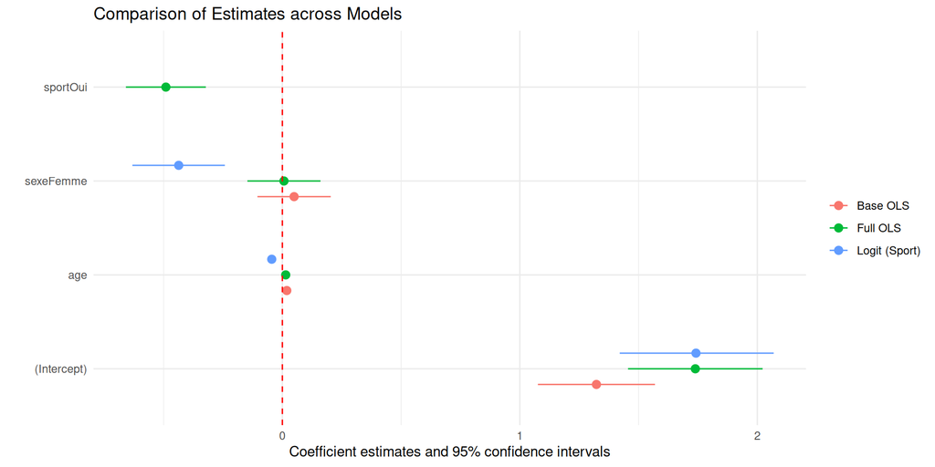

## 💻Pratice

### Exercise 1: Linear Regression ($OLS$)

Using the hdv2003 dataset:

- - Run a linear regression to explain heures.tv (TV hours) using age, sexe, and occup (occupational status). Check for multicollinearity using the VIF.
- Test for heteroscedasticity using the Breusch-Pagan test.

### Exercise 2: Logistic Regression (Logit)

Using the hdv2003 dataset:

- Estimate a logistic regression where the dependent variable is sport (practicing sport). Use age, sexe, and qualif as predictors.
- Display the results as Odds Ratios ($e^\beta$).
- Interpret the effect of age on the chances of practicing sport.

### Exercise 3: Panel Data & Model Comparison

Using the Produc dataset:

- Estimate a Fixed Effects (“within”) model explaining log(gsp) by log(pcap) and unemp.
- Use modelsummary to create a table comparing this model with a simple Pooled OLS version.
- Add significance stars and display standard errors in your table.

# Dimensionality Reduction and Cluster Analysis

## Dimensionality Reduction

- Dimensionality reduction is a technique used to reduce the number of variables in a dataset while retaining as much of the original information as possible
- It is useful for simplifying complex datasets, visualizing high-dimensional data, and improving the performance of machine learning algorithms
- Two common techniques for dimensionality reduction are Principal Component Analysis (PCA) and Multiple Correspondence Analysis (MCA)
- PCA is used for continuous variables, while MCA is used for categorical variables

**Principal Components Analysis (PCA)**

Steps:

1. Standardize the dataset (mean = 0, variance = 1).
2. Compute the covariance matrix (identifies relationships between features).
3. Compute eigenvalues & eigenvectors (find new principal components).
4. Project data onto new principal components (reduce dimensions).

Example: PCA on the Iris dataset.

```r
data("iris")
head(iris)
```

```
  Sepal.Length Sepal.Width Petal.Length Petal.Width Species
1          5.1         3.5          1.4         0.2  setosa
2          4.9         3.0          1.4         0.2  setosa
3          4.7         3.2          1.3         0.2  setosa
4          4.6         3.1          1.5         0.2  setosa
5          5.0         3.6          1.4         0.2  setosa
6          5.4         3.9          1.7         0.4  setosa
```

- `FactoMineR` is used to perform the analysis
- `factoextra` is used to extract information for the analysis and provides visualizations (`fviz_`)

```r
library(FactoMineR)
library(factoextra)

# Perform PCA
iris_num <- iris[, -5]  # Remove the species column
pca_result <- PCA(iris_num, graph=F)  # scaled (mean 0, variance 1) by default
summary(pca_result)
```

```
Call:
PCA(X = iris_num, graph = F)


Eigenvalues
                       Dim.1   Dim.2   Dim.3   Dim.4
Variance               2.918   0.914   0.147   0.021
% of var.             72.962  22.851   3.669   0.518
Cumulative % of var.  72.962  95.813  99.482 100.000

Individuals (the 10 first)
                 Dist    Dim.1    ctr   cos2    Dim.2    ctr   cos2    Dim.3
1            |  2.319 | -2.265  1.172  0.954 |  0.480  0.168  0.043 | -0.128
2            |  2.202 | -2.081  0.989  0.893 | -0.674  0.331  0.094 | -0.235
3            |  2.389 | -2.364  1.277  0.979 | -0.342  0.085  0.020 |  0.044
4            |  2.378 | -2.299  1.208  0.935 | -0.597  0.260  0.063 |  0.091
5            |  2.476 | -2.390  1.305  0.932 |  0.647  0.305  0.068 |  0.016
6            |  2.555 | -2.076  0.984  0.660 |  1.489  1.617  0.340 |  0.027
7            |  2.468 | -2.444  1.364  0.981 |  0.048  0.002  0.000 |  0.335
8            |  2.246 | -2.233  1.139  0.988 |  0.223  0.036  0.010 | -0.089
9            |  2.592 | -2.335  1.245  0.812 | -1.115  0.907  0.185 |  0.145
10           |  2.249 | -2.184  1.090  0.943 | -0.469  0.160  0.043 | -0.254
                ctr   cos2
1             0.074  0.003 |
2             0.250  0.011 |
3             0.009  0.000 |
4             0.038  0.001 |
5             0.001  0.000 |
6             0.003  0.000 |
7             0.511  0.018 |
8             0.036  0.002 |
9             0.096  0.003 |
10            0.293  0.013 |

Variables
                Dim.1    ctr   cos2    Dim.2    ctr   cos2    Dim.3    ctr
Sepal.Length |  0.890 27.151  0.792 |  0.361 14.244  0.130 | -0.276 51.778
Sepal.Width  | -0.460  7.255  0.212 |  0.883 85.247  0.779 |  0.094  5.972
Petal.Length |  0.992 33.688  0.983 |  0.023  0.060  0.001 |  0.054  2.020
Petal.Width  |  0.965 31.906  0.931 |  0.064  0.448  0.004 |  0.243 40.230
               cos2
Sepal.Length  0.076 |
Sepal.Width   0.009 |
Petal.Length  0.003 |
Petal.Width   0.059 |
```

Dim. 1 + Dim. 2 explain 95.8% of the total variance in the data. Dim. 3 adds 4% more variance, but Dim. 4 contributes almost nothing. 2 Dim. is sufficient.

**screeplot**

- The screen plot is a visual representation of the variance explained by each principal component. It helps to decide how many components to keep.
- The elbow method is often used to identify the number of components that explain most of the variance.
- The point where the curve starts to flatten is a good indicator of the number of components to keep.

```r
fviz_screeplot(pca_result)
```

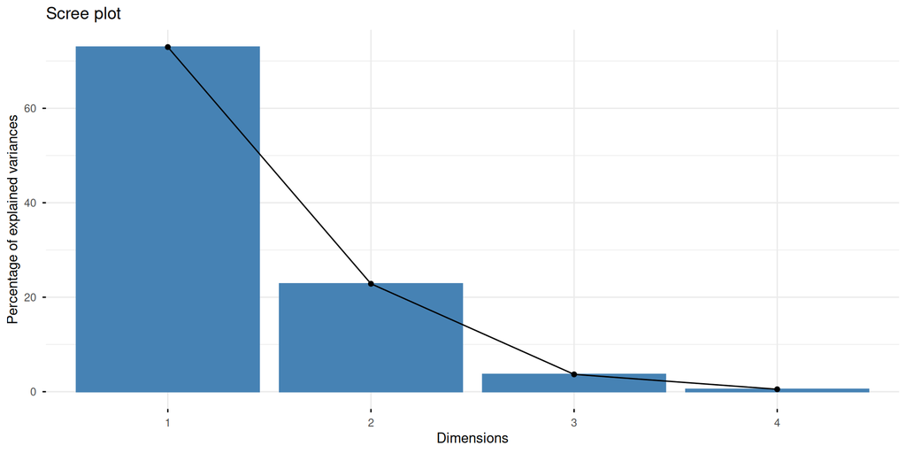

```r
pca_data <- data.frame(pca_result$ind$coord, species=iris$Species)
head(pca_data)
```

```
      Dim.1      Dim.2       Dim.3       Dim.4 species
1 -2.264703  0.4800266 -0.12770602 -0.02416820  setosa
2 -2.080961 -0.6741336 -0.23460885 -0.10300677  setosa
3 -2.364229 -0.3419080  0.04420148 -0.02837705  setosa
4 -2.299384 -0.5973945  0.09129011  0.06595556  setosa
5 -2.389842  0.6468354  0.01573820  0.03592281  setosa
6 -2.075631  1.4891775  0.02696829 -0.00660818  setosa
```

`pca_result$ind$coord` contains the coordinates of the original observations projected onto the principal components (Dimensions). Each row represents an observation (data point), and each column represents a Principal Component (Dim. 1, Dim .2, etc.).

```r
ggplot(pca_data, aes(x = Dim.1, y = Dim.2, color = species)) +
  geom_point(size = 3) +
  labs(title = "PCA Projection of Iris Dataset")
```

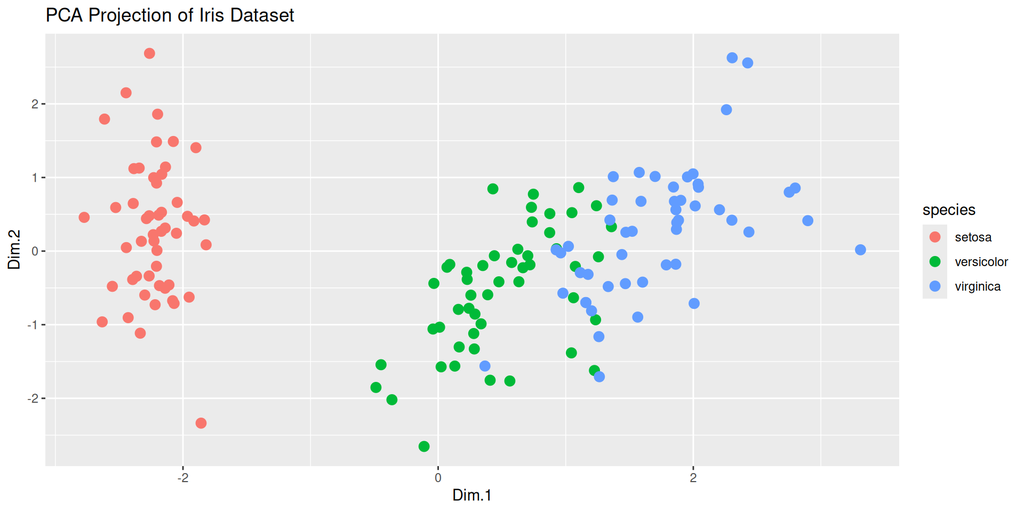

**Biplot**: displays both the observations and the variables on the same plot.  
The observations are represented by points, and the variables are represented by arrows.

```r
fviz_pca_biplot(pca_result, label="var", habillage=as.factor(iris$Species), addEllipses = T, repel = TRUE)
```

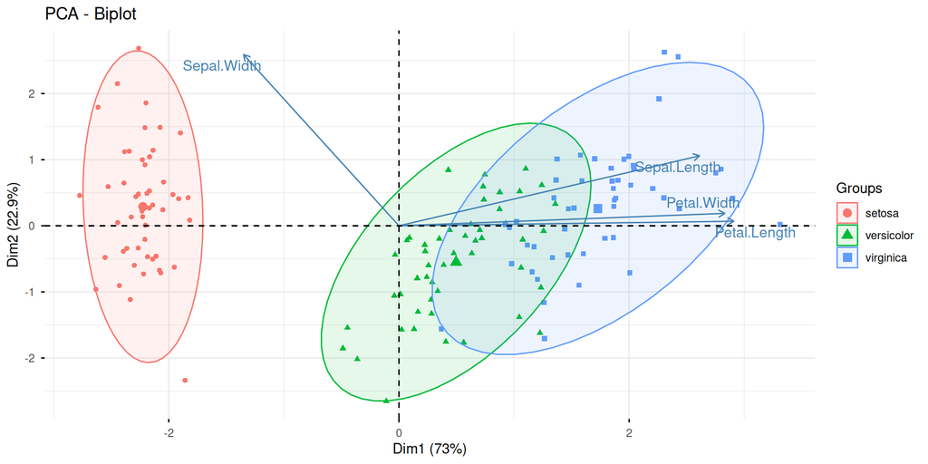

💡 If you have categorical data instead of numeric, use MCA (Multiple Correspondence Analysis) via MCA(data) in the same package.

## K-Means Clustering

K-means clustering is a technique used for **partitioning a dataset into K clusters** based on their similarity. It is an unsupervised learning method that can be used for exploratory data analysis.

Clusters are built around centroids, which are the mean of the data points in each cluster. The goal is to **minimize the sum of squared distances between each data point and the centroid of its cluster, and to maximize the distance between centroids**.

```r
set.seed(123)  # for reproducibility
```

```r
kmeans_result <- kmeans(iris_num, centers = 3, nstart = 25)
kmeans_result
```

```
K-means clustering with 3 clusters of sizes 50, 62, 38

Cluster means:
  Sepal.Length Sepal.Width Petal.Length Petal.Width
1     5.006000    3.428000     1.462000    0.246000
2     5.901613    2.748387     4.393548    1.433871
3     6.850000    3.073684     5.742105    2.071053

Clustering vector:
  [1] 1 1 1 1 1 1 1 1 1 1 1 1 1 1 1 1 1 1 1 1 1 1 1 1 1 1 1 1 1 1 1 1 1 1 1 1 1
 [38] 1 1 1 1 1 1 1 1 1 1 1 1 1 2 2 3 2 2 2 2 2 2 2 2 2 2 2 2 2 2 2 2 2 2 2 2 2
 [75] 2 2 2 3 2 2 2 2 2 2 2 2 2 2 2 2 2 2 2 2 2 2 2 2 2 2 3 2 3 3 3 3 2 3 3 3 3
[112] 3 3 2 2 3 3 3 3 2 3 2 3 2 3 3 2 2 3 3 3 3 3 2 3 3 3 3 2 3 3 3 2 3 3 3 2 3
[149] 3 2

Within cluster sum of squares by cluster:
[1] 15.15100 39.82097 23.87947
 (between_SS / total_SS =  88.4 %)

Available components:

[1] "cluster"      "centers"      "totss"        "withinss"     "tot.withinss"
[6] "betweenss"    "size"         "iter"         "ifault"
```

💡 *Notes:*  
Here we set 3 clusters because we know that the Iris dataset has 3 species.  
But in practice, the number of clusters is often unknown and must be determined using methods like the elbow method, silhouette method, or gap statistic.

We add the cluster column to the original dataset

```r
iris$cluster <- as.factor(kmeans_result$cluster)
table(iris$Species, iris$cluster)
```

```
              1  2  3
  setosa     50  0  0
  versicolor  0 48  2
  virginica   0 14 36
```

Comparison between the clusters and the actual species shows that the clustering algorithm has done a good job of separating the species into different clusters.

**Visualizing the Clusters**

We can visualize the clusters by plotting the first two principal components and coloring the points by cluster.

We indeed saw that with PCA, the first two components explain most of the variance in the data.

```r
ggplot(pca_data, aes(x = Dim.1, y = Dim.2, color = as.factor(kmeans_result$cluster))) +
  geom_point(size = 3) +
  labs(title = "K-Means Clustering on PCA Projection", color = "Cluster")
```

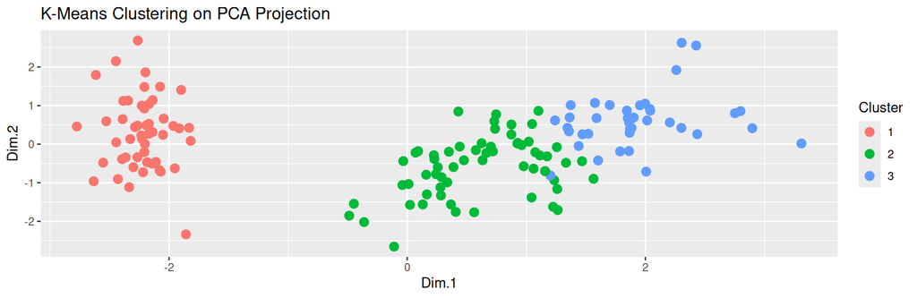

**Choose the optimal number of clusters with the Elbow Method**

The Elbow Method is a heuristic technique used to determine the optimal number of clusters in a dataset. It involves plotting the within-cluster sum of squares (WCSS) against the number of clusters, and looking for the “elbow” point where the rate of decrease slows down.

We test different numbers of clusters (from 1 to 10) and calculate the WCSS for each.

```r
wcss <- numeric(10)
for (i in 1:10) {
  kmeans_result <- kmeans(iris_num, centers = i, nstart = 25)
  wcss[i] <- kmeans_result$tot.withinss
}
```

Then we plot the WCSS against the number of clusters.

```r
ggplot(data.frame(k = 1:10, wcss), aes(x = k, y = wcss)) +
  geom_line() +
  geom_point() +
  labs(title = "Elbow Method for Optimal Number of Clusters", x = "Number of Clusters", y = "Within-Cluster Sum of Squares")
```

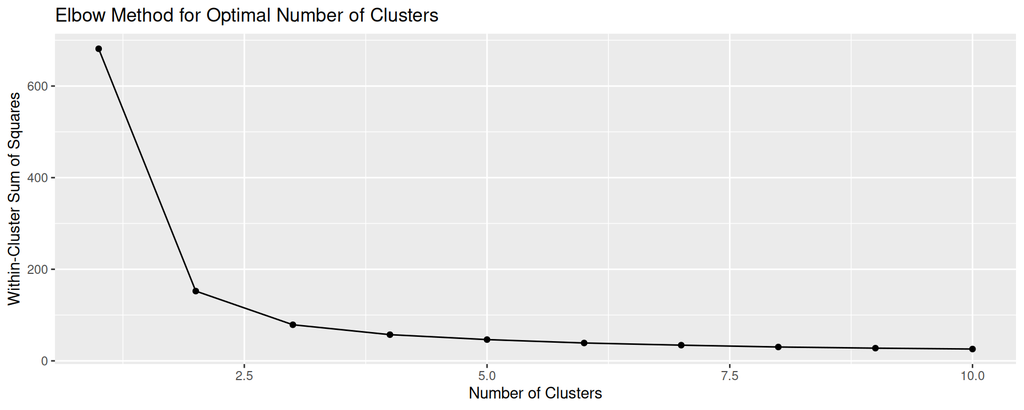

# The Reproducible Kit

To ensure your research is transparent, portable, and future-proof:

- RStudio Projects (.Rproj): It keeps all data, scripts, and outputs in one self-contained folder.
- Quarto (.qmd): The bridge between your code and your manuscript. It integrates citations, cross-references, and dynamic analysis in one document.
- `here` Package: Eliminates absolute paths. Your code will run on any computer because paths are relative to your project root.
- `renv Package`: “Freezes” your environment. It records the exact version of every package you use, preventing future updates from breaking your old analysis.
- Version Control (Git): Your “Time Machine”. It tracks every change in your code, allows you to revert errors, and facilitates safe collaboration.

💡 Reproductibility is a gift to your future self. In three years, when you need to re-run your models for a “Minor Revision” from a journal, you will be glad you followed these steps!

# Sources

- https://www.r-tutor.com/r-introduction
- [a complete book on data analysis with R](https://larmarange.github.io/analyse-R/analyse-R.pdf)
- [the class of Julien Barnier](https://juba.github.io/tidyverse/index.html)
- https://www.tidyverse.org/
- http://ggplot2.tidyverse.org/reference/
- [a lot of graph examples with ggplot2](http://www.cookbook-r.com/Graphs/)
- [R Graphics Cookbook – Winston Chang](https://r-graphics.org/)
- [R for data science](https://r4ds.had.co.nz/index.html)
- [R for Data Science (R4DS) – Hadley Wickham & Garrett Grolemund](https://r4ds.hadley.nz/)
- [Hands-On Machine Learning with R – Bradley Boehmke & Brandon Greenwell](https://bradleyboehmke.github.io/HOML/)
- [The Art of Data Science – Roger D. Peng & Elizabeth Matsui](https://bookdown.org/rdpeng/artofdatascience/)